# Xiao Hui Tai

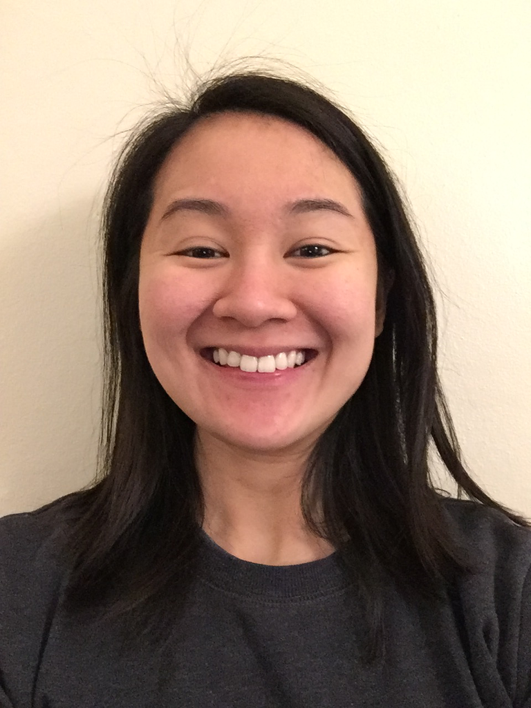

Assistant Professor  
Department of Statistics  
University of California, Davis

- **Email**: xtai [at] ucdavis [dot] edu
- [CV](https://github.com/xhtai/xhtai.github.io/blob/master/tai_cv.pdf)
- [Google Scholar](https://scholar.google.com/citations?user=6gkGxMcAAAAJ&hl=en&oi=sra) page
- GitHub: xhtai
- [LinkedIn](https://www.linkedin.com/in/xiao-hui-tai)

I am an assistant professor at the [Statistics](https://statistics.ucdavis.edu/) department at [U.C. Davis](https://www.ucdavis.edu/).

I am interested in using large-scale, granular sources of data, and statistical and machine learning methods, to measure and study human behavior. My current research is focused on global public health and estimating the social and economic consequences of violent conflict. You can find a magazine article about my recent work [here](https://lettersandsciencemag.ucdavis.edu/self-society/how-statistics-informs-social-science-research-xiao-hui-tai).

Before this, I was a postdoctoral researcher at the [School of Information](https://www.ischool.berkeley.edu/) at [U.C. Berkeley](https://www.berkeley.edu/), working with [Josh Blumenstock](http://www.jblumenstock.com/) at the [Global Policy Lab](https://www.globalpolicy.science/) (formerly the [Data-Intensive Development Lab](https://didl.berkeley.edu)). I graduated from [Carnegie Mellon University](https://www.cmu.edu/) with a PhD in [Statistics](http://www.stat.cmu.edu/). I was advised by [Bill Eddy](http://www.stat.cmu.edu/~bill/), and also worked closely with [Nicolas Christin](https://www.andrew.cmu.edu/user/nicolasc/)’s group at [CyLab](https://www.cylab.cmu.edu/), CMU’s university-wide security institute.

I am originally from Singapore and was previously a government statistician at the [Department of Statistics](https://www.singstat.gov.sg/). I also spent some time at [J.P. Morgan Chase](https://www.jpmorganchase.com/) as a quantitative modeler.

My first name is “Xiao Hui” (not Xiao!), and my last name is Tai.

### News

09/2025 I will give a talk at the [21st Annual Workshop of the Households in Conflict Network](https://isdc.org/events/fragile-lives-2025/).

06/2025 I will give a talk at the [WNAR/IMS Annual Meeting](https://wnarofibs.wildapricot.org/wnar2025) in Whistler, Canada.

06/2025 I will give a talk at the [20th Australasian Development Economics Workshop](https://conference.unsw.edu.au/en/adew-2025) in Sydney, Australia.

02/2025 I will be part of an invited panel Climate and Conflict: Measurement Challenges with Forced Migration, at the University of Michigan.

11/2024 My paper estimating the effect of armed conflict on female education in Africa was accepted to PLOS ONE.

11/2024 I will give a talk at the [Conference on Statistical Learning and Data Science](https://sites.google.com/view/slds2024/menu?authuser=0) on November 6.

10/2024 Our work on conflict and internal displacement in Afghanistan was featured in [Undark magazine](https://undark.org/2024/10/16/war-public-health-vast-impact/).

10/2024 I am a [Hellman Fellow](https://www.ucdavis.edu/news/newest-hellman-fellows-have-wide-range-expertise?utm_source=datelinehtml&utm_medium=datelinenewsletter&utm_campaign=dateline_20241119) for 2024-25.

### Publications

**Xiao Hui Tai**. [Nearby Armed Conflict Affects Girls’ Education in Africa](https://journals.plos.org/plosone/article?id=10.1371/journal.pone.0314106). *PLOS ONE*. 2025.

Pablo Busch, Paulo Rocha, Kyung Jin Lee, Luis Abdón Cifuentes and **Xiao Hui Tai**. [Short-term exposure to fine particulate pollution and elderly mortality in Chile](https://www.nature.com/articles/s43247-024-01634-x). *Communications Earth & Environment*. 2024. [[Code]](https://github.com/pmbusch/PM25-Satellite-Chile/)

Yury Elena Garcia Puerta, Miryam Elizabeth Villa-Perez, Kuang Li, **Xiao Hui Tai**, Luis A. Trejo, Maria L. Daza–Torres, J. Cricelio Montesinos-Lopez and Miriam Nuno. [Wildfires and Social Media Discourse: Exploring Mental Health and Emotional Well-Being Through Twitter](https://www.frontiersin.org/journals/public-health/articles/10.3389/fpubh.2024.1349609/full). *Frontiers in Public Health*. 2024.

Arogya Koirala, Suraj R. Nair and **Xiao Hui Tai**. [Mapping Opium Poppy Cultivation: Socioeconomic Insights from Satellite Imagery](https://dl.acm.org/doi/10.1145/3648435). *ACM Journal on Computing and Sustainable Societies*. 2024. [[Code]](https://github.com/arogyakoirala/poppy) Early versions: 4th ACM SIGCAS Conference on Computing and Sustainable Societies (COMPASS ’21) (poster track); 27th ACM SIGKDD Conference on Knowledge Discovery and Data Mining (KDD ’21), Workshop on Humanitarian Mapping

**Xiao Hui Tai**, Shikhar Mehra and Joshua E. Blumenstock. [Mobile Phone Data Reveal the Effects of Violence on Internal Displacement](https://www.nature.com/articles/s41562-022-01336-4). *Nature Human Behavior*. 2022. [[Code]](https://github.com/Global-Policy-Lab/afghanistan-internal-displacement)

Cornelia Ilin*, Sébastien Annan-Phan*, **Xiao Hui Tai***, Shikhar Mehra, Solomon Hsiang and Joshua E. Blumenstock. [Public Mobility Data Enables COVID-19 Forecasting and Management at Local and Global Scales](https://www.nature.com/articles/s41598-021-92892-8). *Nature Scientific Reports.* 2021. (* indicates equal contribution) [[Radio show]](https://www.mixcloud.com/Radio4Brainport/tea-talk-with-karishma-and-supriya-university-of-berkeley-fighting-poverty-with-data/)

**Xiao Hui Tai** and Kayla Frisoli. Benchmarking Minimax Linkage in Hierarchical Clustering. *Data Analysis and Rationality in a Complex World.* Springer International Publishing, 2021. [[Code]](https://github.com/xhtai/clusterTruster)

**Xiao Hui Tai**, Kyle Soska and Nicolas Christin. [Adversarial Matching of Dark Net Market Vendor Accounts](https://dl.acm.org/citation.cfm?doid=3292500.3330763). *Proceedings of the 25th ACM SIGKDD International Conference on Knowledge Discovery & Data Mining (KDD).* 2019. [[Code]](https://github.com/xhtai/adversarial-matching) [[Video]](https://www.dropbox.com/s/8pagghqg2jpfasb/taiSoskaChristin.mp4?dl=0)

**Xiao Hui Tai**. [Record Linkage and Matching Problems in Forensics](https://ieeexplore.ieee.org/document/8637441). *IEEE 18th International Conference on Data Mining Workshops (ICDMW)*. IEEE, 2018.

**Xiao Hui Tai** and William F. Eddy. [A Fully Automatic Method for Comparing Cartridge Case Images](http://onlinelibrary.wiley.com/doi/10.1111/1556-4029.13577/abstract). *Journal of Forensic Sciences*. 2018. [[Code]](https://github.com/xhtai/cartridges)

### Book Reviews, Chapters and Magazine Articles

**Xiao Hui Tai**. [Data Science in Practice](https://www.tandfonline.com/doi/full/10.1080/00031305.2025.2490304). *The American Statistician*. 2025.

**Xiao Hui Tai**. [Counting the true cost of war](https://academic.oup.com/jrssig/article-abstract/22/2/18/7998831). *Significance* (cover article). 2025.

Susan VanderPlas, Alicia Carriquiry, Heike Hofmann, James Hamby and **Xiao Hui Tai**. [An Introduction to Firearms Examination for Researchers in Statistics](https://books.google.com/books?hl=en&lr=&id=f_cFEAAAQBAJ&oi=fnd&pg=PA365&dq=info:m77td9YyRJ8J:scholar.google.com&ots=DlwchSEoIz&sig=pWht9GJ6WxwEd4otg5MaS7bShb8#v=onepage&q&f=false). *Handbook of Forensic Statistics*. 2021.

Sam Tyner, Soyoung Park, Ganesh Krishnan, Karen Pan, Eric Hare, Amanda Luby, **Xiao Hui Tai**, Heike Hofmann, and Guillermo Basulto-Elias. 2019. [OpenForSciR: Open Forensic Science in R](https://sctyner.github.io/OpenForSciR/). 2019.

Alicia Carriquiry, Heike Hofmann, **Xiao Hui Tai** and Susan VanderPlas. [Machine Learning in Forensic Applications](https://rss.onlinelibrary.wiley.com/doi/epdf/10.1111/j.1740-9713.2019.01252.x). *Significance*. 2019.

### Pre-prints

**Xiao Hui Tai** and Olga Shemyakina. Conflict in Adolescence Has Long-term Effects on Women’s Economic Empowerment in Africa. *In submission*.

**Xiao Hui Tai**. Estimating the effect of violence on lifespan inequality using a spatio-temporal causal inference approach. *In submission*.

**Xiao Hui Tai**, Suraj R. Nair, Shikhar Mehra and Joshua E. Blumenstock. [Satellite and Mobile Phone Data Reveal How Violence Affects Seasonal Migration in Afghanistan](https://arxiv.org/abs/2507.00279). *In revision* at Nature Communications.

**Xiao Hui Tai** and William F. Eddy. [Automatically Matching Topographical Measurements of Cartridge Cases Using a Record Linkage Framework](https://arxiv.org/abs/2003.00060). *arXiv:2003.00060*.

### Teaching

In Fall 2022, 2023 and 2024, I taught [STA 35A](https://xhtai.github.io/statdatasci), a new introductory statistical data science course for data science majors at UC Davis.

In Fall 2023 and 2024, I also taught STA 160 Practice in Statistical Data Science, an undergraduate capstone course.

I taught STA 141C Big Data and High Performance Statistical Computing in Spring 2024.

In Winter 2023, I taught STA 250, a research seminar on Data Science for International Development.

Last updated: 2025-07-18.